# ST558-Project-2

Jenna Wilkie 10/22/2021

```r
library(tidyverse)
library(caret)
library(randomForest)
library(gbm)
library(doParallel)
```

# Intoduction

The data set collected from different articles was published by Mashable (www.mashable.com) with the last two years. We mainly subset six different channels: lifestyle, entainment, business, socmed, tech and world to predict the probability of online news popularity.  
In this project, we summarized and plot some parameters (predictors) against shares (response). Furthermore, we use four different methods - two linear models, a random forest and a boosted tree models - to model the response (shares of articles) from different articles on Mashable website and predict the popularity of online news.

# Reading in Data Set

To begin, we read in the data set, then created a subset of the data to look at only the news article type that we are interested in. A variable named “channel” was added to allow us to automate R markdown documents based on article type.

```r
data<-online_news_popularity<-read_csv("OnlineNewsPopularity.csv")

#create new variable for channel then filter for data to select the chanel of interest
data <- data %>%
  mutate(channel= if_else(data_channel_is_bus == 1,"bus",
                          if_else(data_channel_is_lifestyle == 1, "lifestyle",
                          if_else(data_channel_is_entertainment == 1, "entertainment",
                          if_else(data_channel_is_tech == 1, "tech",
                          if_else(data_channel_is_world == 1, "world", "socmed"))))))
```

```r
data<-filter(data,channel=="entertainment")
```

# Summarizations

Next we will look at some summary statistics of the data.

## Summary Statistics

To start, we want to take a look at some important summary statistics of the data.

```r
shares_avg<-mean(data$shares)
shares_sd<-sd(data$shares)

shares_avg
```

```
## [1] NA
```

```r
shares_sd
```

```
## [1] NA
```

Another thing that could be interesting is which day of the week has the most shares for this type of article and how many shares occur in total for each day of the week. The averages will give us the expected number of shares for each day, and the summation will give us a total count of the number of shares that have occurred overall.

```r
mon_avg<-data%>%filter(weekday_is_monday == 1)
tue_avg<-data%>%filter(weekday_is_tuesday==1)
wed_avg<-data%>%filter(weekday_is_wednesday==1)
thu_avg<-data%>%filter(weekday_is_thursday==1)
fri_avg<-data%>%filter(weekday_is_friday==1)
sat_avg<-data%>%filter(weekday_is_saturday==1)
sun_avg<-data%>%filter(weekday_is_sunday==1)

mon_sum<-data%>%filter(weekday_is_monday == 1)
tue_sum<-data%>%filter(weekday_is_tuesday==1)
wed_sum<-data%>%filter(weekday_is_wednesday==1)
thu_sum<-data%>%filter(weekday_is_thursday==1)
fri_sum<-data%>%filter(weekday_is_friday==1)
sat_sum<-data%>%filter(weekday_is_saturday==1)
sun_sum<-data%>%filter(weekday_is_sunday==1)

avgs<-data.frame("Avg"=c(mean(mon_avg$shares),mean(tue_avg$shares),mean(wed_avg$shares),mean(thu_avg$shares),mean(fri_avg$shares),mean(sat_avg$shares),mean(sun_avg$shares)), "Day"=c("Mon", "Tues", "Wed", "Thur", "Fri", "Sat", "Sun"))

sums<-data.frame("Value"=c(sum(mon_sum$shares),sum(tue_sum$shares),sum(wed_sum$shares),sum(thu_sum$shares),sum(fri_sum$shares),sum(sat_sum$shares),sum(sun_sum$shares)), "Day"=c("Mon", "Tues", "Wed", "Thur", "Fri", "Sat", "Sun"))

avgs
```

```
##        Avg  Day
## 1 2931.036  Mon
## 2 2708.033 Tues
## 3 2854.619  Wed
## 4 2882.213 Thur
## 5 3000.947  Fri
## 6 3416.400  Sat
## 7 3810.951  Sun
```

```r
sums
```

```
##     Value  Day
## 1 3980347  Mon
## 2 3479822 Tues
## 3 3696732  Wed
## 4 3548004 Thur
## 5 2916920  Fri
## 6 1298232  Sat
## 7 2042670  Sun
```

We are interested in the impact of global rate positive words and global rate negative words on shares. Also, we compared with rate positive words and negative words.

```r
avg_global_pos <- mean(data$global_rate_positive_words)
var_global_pos  <- sd(data$global_rate_positive_words)
avg_global_pos
```

```
## [1] 0.04047572
```

```r
var_global_pos
```

```
## [1] 0.01692767
```

```r
avg_global_neg  <- mean(data$global_rate_negative_words)
var_global_neg <- sd(data$global_rate_negative_words)
avg_global_neg
```

```
## [1] 0.01905456
```

```r
var_global_neg
```

```
## [1] 0.01252802
```

```r
avg_rate_pos <- mean(data$rate_positive_words)
var_rate_pos <- sd(data$rate_positive_words)
avg_rate_pos
```

```
## [1] 0.6663317
```

```r
var_rate_pos
```

```
## [1] 0.1850866
```

```r
avg_rate_neg <- mean(data$rate_negative_words)
var_rate_neg<- sd(data$rate_negative_words)
avg_rate_neg
```

```
## [1] 0.3050442
```

```r
var_rate_neg
```

```
## [1] 0.1546417
```

We want to inspect impact of number of images and videos on shares of articles.

```r
avg_num_imgs <- mean(data$num_imgs)
var_num_imgs <- sd(data$num_imgs)
avg_num_imgs
```

```
## [1] 6.317699
```

```r
var_num_imgs
```

```
## [1] 11.62707
```

```r
avg_num_videos <- mean(data$num_videos)
var_num_videos <- sd(data$num_videos)
avg_num_videos
```

```
## [1] 2.545841
```

```r
var_num_videos
```

```
## [1] 6.225034
```

## Graphs

[figure not shown]

```r
# change the shape of the data for easy graphing.
ggplot(data=avgs, aes(x=Day, y=Avg))+geom_bar(stat="Identity", fill="light blue")+geom_abline(aes(intercept=shares_avg,slope=0), color="red")+labs(x="Day of the Week", y="Number of Shares", title="Article Day of Week")+scale_x_discrete(labels=c("Monday", "Tuesday", "Wednesday","Thursday", "Friday", "Saturday","Sunday"))
```

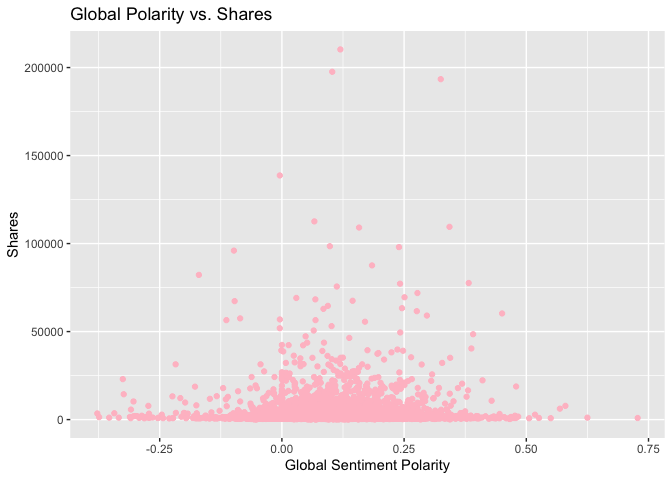

```r
correlation<-cor(data$global_sentiment_polarity, data$shares)
ggplot(data, aes(x=global_sentiment_polarity, y=shares))+geom_point(color="pink")+labs(x="Global Sentiment Polarity", y="Shares" ,title="Global Polarity vs. Shares")+geom_text(x=0.5, y=6e+05, size=4 ,label=paste0("Correlation=",round(correlation,2)))
```

It may also be worth it to look at a facet wrap of polarity against shares grouped by the day of the week. Each plot shows a scatter plot of each day of the week with the global_sentiment_polarity vs.shares for that day. In each plot, look for a shape that indicates a straight line. If the plot appears to resemble a straight line, then that relationship is linear.

[figure not shown]

```r
#create a temporary data set with a variable for the days of the week
data_weeks<-data %>%
  mutate(day=if_else(weekday_is_monday == 1,"Monday",
                          if_else(weekday_is_tuesday == 1, "Tuesday",
                          if_else(weekday_is_wednesday == 1, "Wednesday",
                          if_else(weekday_is_thursday == 1, "Thursday",
                          if_else(weekday_is_friday == 1, "Friday",if_else(weekday_is_saturday==1,"Saturday", "Sunday")))))))

#plot data set grouped by day of week

ggplot(data=data_weeks, aes(x=shares, y=global_sentiment_polarity))+geom_point()+facet_wrap(~day)
```

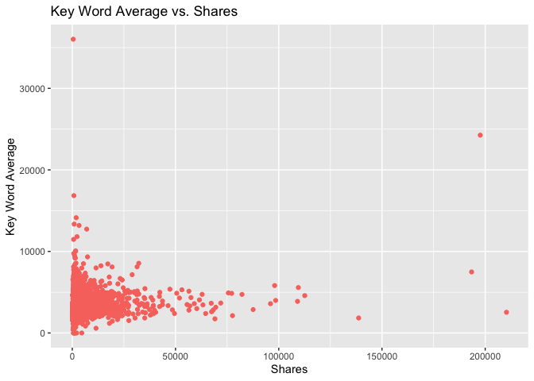

```r
correlation<-cor(data$shares, data$kw_avg_avg)
ggplot(data, aes(x=shares, y=kw_avg_avg))+geom_point(color="#F8766D")+labs(x="Shares", y="Key Word Average" ,title="Key Word Average vs. Shares")+geom_text(x=6e+05, y=40000, size=3 ,label=paste0("Correlation=",round(correlation,2)))
```

We think the global rate positive words and negative words would have some impact on shares. So we plot scatter plots. If correlation between global rate positive words or negative words and shares is small, which means the global rate positive and negative words barely have influence on people’s sharing an article. Otherwise, there is a high correlation.

```r
correlation_global_pos<-cor(data$global_rate_positive_words, data$shares)
correlation_global_pos
```

```
## [1] -0.01844167
```

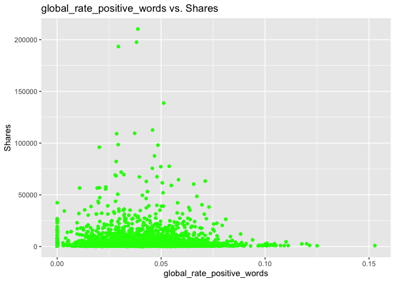

```r
ggplot(data, aes(x=global_rate_positive_words, y=shares))+geom_point(color="green")+labs(x="global_rate_positive_words", y="Shares" ,title="global_rate_positive_words vs. Shares")+geom_text(x=0.10, y=6e+05, size=4,label = paste0("Correlation =", round(correlation_global_pos,2)))
```

```r
correlation_global_neg<-cor(data$global_rate_negative_words, data$shares)
correlation_global_neg
```

```
## [1] -0.01360618
```

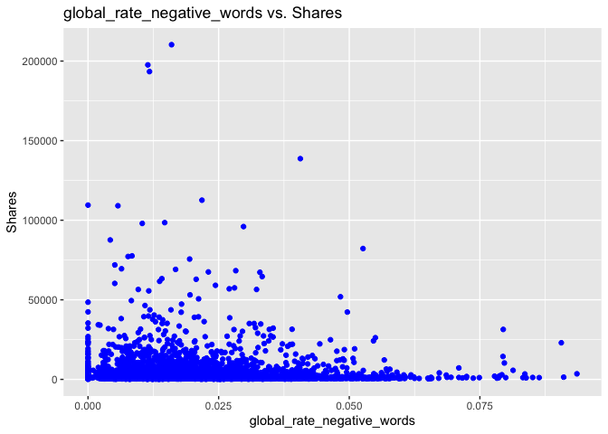

```r
ggplot(data, aes(x=global_rate_negative_words, y=shares))+geom_point(color="blue")+labs(x="global_rate_negative_words", y="Shares" ,title="global_rate_negative_words vs. Shares")+geom_text(x=0.06, y=6e+05, size=4, label = paste0("Correlation = " , round(correlation_global_neg,2)))
```

Also, we inspect the impact of rate positive words and negative words on shares. Based on the result, we can conclude which has higher correlation with shares, rate negative words or rate positive words.

```r
correlation_rate_pos<-cor(data$rate_positive_words, data$shares)
correlation_rate_pos
```

```
## [1] 0.005400506
```

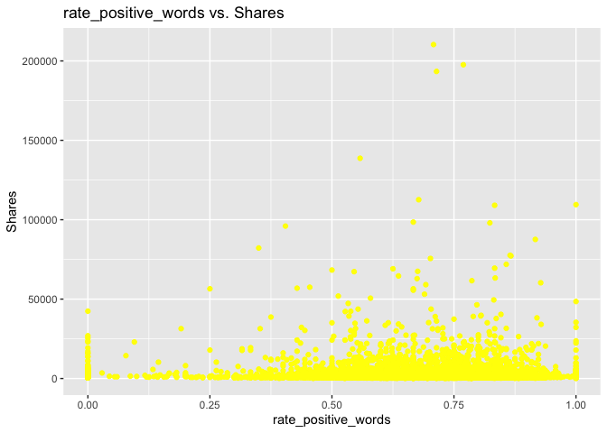

```r
ggplot(data, aes(x=rate_positive_words, y=shares))+geom_point(color="yellow")+labs(x="rate_positive_words", y="Shares" ,title="rate_positive_words vs. Shares")+geom_text(x=0.22, y=7e+05, size=4,label = paste0("Correlation =", round(correlation_rate_pos,2)))
```

```r
correlation_rate_neg<-cor(data$rate_negative_words, data$shares)
correlation_rate_neg
```

```
## [1] -0.006778685
```

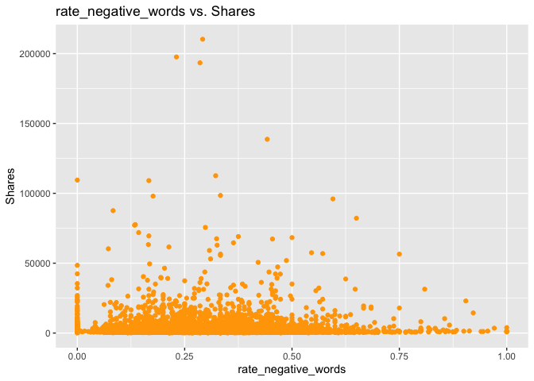

```r
ggplot(data, aes(x=rate_negative_words, y=shares))+geom_point(color="orange")+labs(x="rate_negative_words", y="Shares" ,title="rate_negative_words vs. Shares")+geom_text(x=0.22, y=7e+05, size=4,label = paste0("Correlation =", round(correlation_rate_neg,2)))
```

We are interested in influence of number of images and videos on shares. Based on result, we may see the relationship between number of images or videos and shares of articles, whether shares went up with increase of number of images or videos or not.

```r
correlation_imgs<-cor(data$num_imgs, data$shares)
correlation_imgs
```

```
## [1] 0.03809298
```

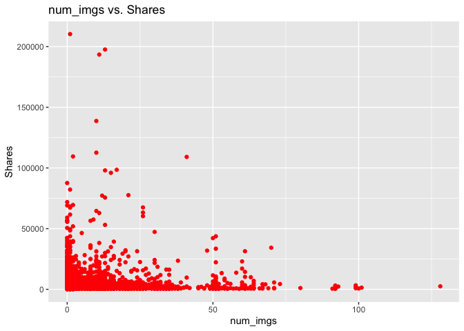

```r
ggplot(data, aes(x=num_imgs, y=shares))+geom_point(color="red")+labs(x="num_imgs", y="Shares" ,title="num_imgs vs. Shares")+geom_text(x=40, y=7e+05, size=4,label = paste0("Correlation =", round(correlation_imgs,2)))
```

```r
correlation_videos<-cor(data$num_videos, data$shares)
correlation_videos
```

```
## [1] -0.0005863698
```

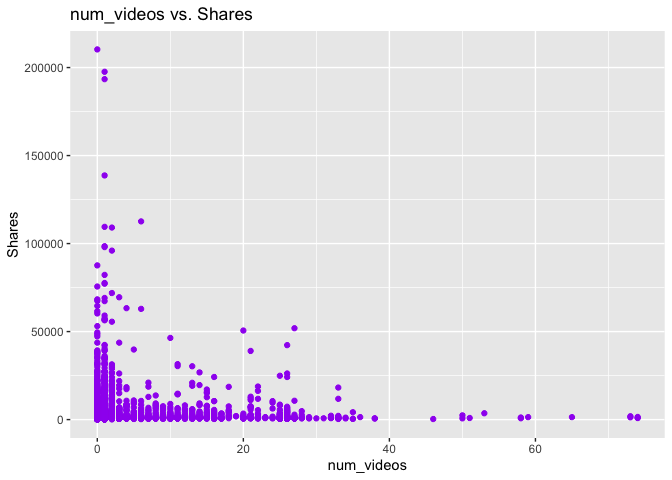

```r
ggplot(data, aes(x=num_videos, y=shares))+geom_point(color="purple")+labs(x="num_videos", y="Shares" ,title="num_videos vs. Shares")+geom_text(x=60, y=7e+05, size=4,label = paste0("Correlation =", round(correlation_videos,2)))
```

# Modeling

Based on the trends above, and common knowledge, we will fit a two linear models, a random forest model, and a boosted tree model for comparison.

```r
# set seed for reproduceability
set.seed(89)

train_index<-createDataPartition(data$shares, p=0.7, list=FALSE)
training<-data[train_index,]
test<-data[-train_index,]
```

## Linear Regression Models

A linear regression model allows us to predict the response of a variable of interest, in this case the **shares** variable, based on a selected set of predictors. A simple linear regression model can be written as y=Beta_0+Beta_1*x, where Beta_0 is the intercept, Beta_1 is the slope, x is the predictor variable, and y is the response. Multiple linear regression models can be used in instances where multiple possible predictors are present. In those cases there will be a slope for each predictor to account for the effect that predictor can have on the response.

```r
set.seed(89)

linear_fit_1 <- train(shares~self_reference_avg_sharess+abs_title_sentiment_polarity+abs_title_subjectivity+avg_positive_polarity+avg_negative_polarity+is_weekend+rate_positive_words+rate_negative_words, data=training, method = "lm", trControl=trainControl(method="cv", number=5),preProcess = c("center", "scale"))

linear_fit_1
```

[output not shown]

```r
set.seed(89)

linear_fit_2 <- train(shares~global_rate_negative_words+num_imgs+ global_rate_negative_words:num_imgs+I(global_rate_negative_words^2)+I(num_imgs^2), data=training, method = "lm", trControl=trainControl(method="cv", number=5),preProcess = c("center", "scale"))

linear_fit_2
```

[output not shown]

## Ensemble Models

### Random Forest Model

A random forest model creates multiple trees from bootstrap analysis then averages the results. Random forest models randomly select a subset of predictors for averaging, so the results won’t be affected by one or two very strong predictors. Below is a random forest model fitted from the data. The model self reference shares, absolute title sentiment polarity, absolute title subjectivity, average positive polarity, average negative polarity, rate positive words, and rate negative words as predictors.

```r
set.seed(89)

#use parallel computing to speed up process on four cores
cl <- makePSOCKcluster(4)
registerDoParallel(cl)

random_forest_fit <- train(shares~self_reference_avg_sharess+abs_title_sentiment_polarity+abs_title_subjectivity+avg_positive_polarity+avg_negative_polarity+is_weekend+rate_positive_words+rate_negative_words, data=training, method = "rf", trControl=trainControl(method="cv", number=10),preProcess = c("center", "scale"), tuneGrid=data.frame(mtry=(1:6)))


random_forest_fit
```

[output not shown]

### Boosted Tree Model

A boosted tree model was created. Ensemble boosting tree approach can be applied to make trees grown sequentially, each subsequent tree grown on a modified version of original data (slow fitting because of shrinkage), and predictions updated as trees grown. Because the tree grown was shrink for slow fitting, so the appropriate interpretation of trees was lost.

```r
set.seed(89)
#create cores for parallel computing
cl <- makePSOCKcluster(4)
registerDoParallel(cl)

boosted_tree_fit <-
  train(shares ~ self_reference_avg_sharess+weekday_is_tuesday+weekday_is_wednesday+weekday_is_thursday+weekday_is_friday+global_rate_positive_words+global_rate_negative_words+num_imgs+num_videos, data=training, method = "gbm", trControl=trainControl(method="cv", number=5),preProcess = c("center", "scale"), tuneGrid=expand.grid(n.trees=c(10,20,50,100,200), interaction.depth = c(1,2,3,4), shrinkage = 0.1, n.minobsinnode = 10))
boosted_tree_fit
```

[output not shown]

# Compairson

```r
set.seed(89)
pred_linear_1<-predict(linear_fit_1, test)
pred_linear_2<-predict(linear_fit_2, test)
pred_random_fit<-predict(random_forest_fit, test)
pred_boosted_fit<-predict(boosted_tree_fit, test)
linear_1<-postResample(pred_linear_1,test$shares)
linear_2<-postResample(pred_linear_2,test$shares)
random_fit<-postResample(random_forest_fit$bestTune,test$shares)
boosted_fit<-postResample(boosted_tree_fit$bestTune,test$shares)

results<-data.frame("Model"=c("Linear Model 1", "Linear Model 2", "Random Forest Model", "Boosted Tree Model"),"RMSE"=c(linear_1[1],linear_2[1],random_fit[1],boosted_fit[1]))
```

```r
#Find the minimum RMSE value
min_rmse<-min(results$RMSE)

#use a for loop to find the index of the minimum rmse value and use that index to return the linear model associated with that rmse.
for(i in 1:4){
  if (results[i,2]==min_rmse){
  model<-results[i,1]
  }
}
```

```r
#paste the automated result

paste0("The best predictor model of the ones we've created was selected by choosing the model with the lowest RMSE value.  For this type of article, the best model is ", model,".")
```

```
## [1] "The best predictor model of the ones we've created was selected by choosing the model with the lowest RMSE value.  For this type of article, the best model is Linear Model 2."
```